# **Introduction**

A recent study shows that only 16% of Canadians are getting restful sleep every night of the week [1]. Inadequate sleep is associated with several chronic illnesses and conditions, including type 2 diabetes, heart disease, obesity, and depression, posing a significant threat to public health. A lack of sleep is not only dangerous in the health problems it can cause, but it also contributes to motor vehicle accidents and workplace errors, resulting in numerous injuries and disabilities annually. Inadequate sleep/ sleep quality can be caused by several disorders. However, currently, sleep research faces a major challenge.

While sleep logs are a common method for annotating sleep data, they often miss out on capturing the finer details, like the difference between heading to bed and actually falling asleep [2]. Similarly, heuristic-based software which tries to identify sleep patterns based on human-engineered features often misinterprets the nuances that experts can visually detect from their data.

The project's goal is to develop a model that could wrist-worn accelerometer data to **pinpoint the precise moment an individual fell asleep and woke up**. This would not only enable researchers to undertake large-scale sleep studies with more accuracy but would also pave the way for deeper insights into how sleep is affected by various environmental factors. Such data and analysis could subsequently lead to personalized interventions and support systems for children, especially those facing mood and behavioral challenges. A reliable tool to detect sleep patterns can aid in understanding and addressing sleep disturbances in younger populations.

# **Data**

## Data Breakdown

We were provided labelled training data that consisted of the event dataset and the series dataset. Below you can see the first 5 rows in each dataset and a breakdown of each column in each dataset. The data can be broken down by series_id which are unique numerical identifiers that were assigned to each individual the data was collected from. Participants collected sleep data for 2-500 nights. Each complete night of data (with one sleep and wake event within that night) will be referred to as an 'observation' from this point. This is to ensure that observations are not confused with the 'night' column in the event dataset that identifies the night # within the series.

Here is a breakdown of each dataframe by column.

**series dataset:**

> - **series_id** - This is a unique identifier for each accelerometer series. Each unique series_id corresponds to the data of a unique individual.
- **step** - An integer timestep for each observation within a series.
- **timestamp** - A corresponding datetime with ISO 8601 format %Y-%m-%dT%H:%M:%S%z. Note that for each observation within a series, data is collected for every 5 seconds
- **anglez** - A metric derived from individual accelerometer components that refers to the angle of the wrist or the position of the accelerometer in relation to gravity.
- **enmo** - ENMO stands for Euclidean Norm Minus One. The Euclidean norm is a way of calculating the magnitude of the vector representing the accelerometer's readings on the X, Y, and Z axes. By subtracting one from this norm, the ENMO metric adjusts for gravity and provides a measure of movement intensity that is more directly related to physical activity.

**event dataset:**

> - **series_id** - Unique identifier for each accelerometer series that corresponds to the data of a unique individual.
- **night** - An integer that corresponds to the night within a series that the data was recorded.
- **event** - This is the labelled data. the labels (onset/wakeup) identify the precise moment that a sleep onset or a wake event occured. In other words, sleep onset identifies the precise moment the participant fell asleep, and wakeup identifies the precise moment the participant woke up.
- **step** - An integer timestep for each observation within a series.
- **timestamp** - A corresponding datetime with ISO 8601 format %Y-%m-%dT%H:%M:%S%z.

[figure not shown]

As you can see, the series dataset is very large. It contains 127 million rows of sleep data. In comparison the event dataset with the labelled sleep events is only 14 thousand rows.

This means that the frequency of a sleep/ wake event (i.e. when the moment the participant falls asleep/ wakes up) is roughly **0.01%**. The vast majority of the data is data collected while the participant is sleeping or while they are awake (before falling asleep/ after waking up).

Next we will visualize a few observations to see if we can identify any relationships/ patterns in the data.

[figure not shown]

## Data Pre-processing

After understanding the data and checking as many series as possible, we encountered our first issue: some inconsistencies in the datasets, such as duplicated or redundant lines, as well as 'NAs' in the events data. For example, there were days when two 'sleep' events occurred, and the 'awake' event had an offset of one hour, as shown in the image below. Therefore, preprocessing and cleaning of the data were necessary

The second issue we faced was the size of our data; we had 3416.54 MB of data to train with. Therefore, the folling optimization process also reduced the data to 2059.05 MB, aiming to alleviate the training processes and prevent memory overload

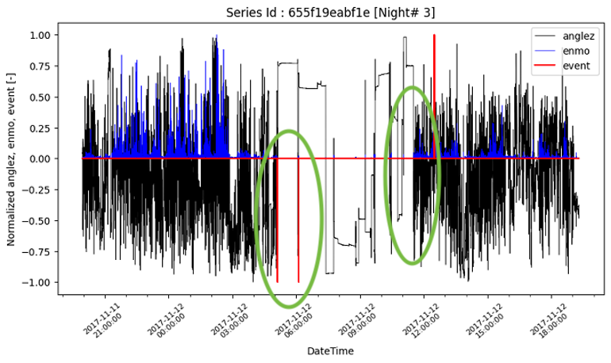

Data Pre-proccessing - Load Data Bases from Competation

```python
#import neccesary libraries
import numpy as np
import pandas as pd
import polars as pl
import warnings
warnings.filterwarnings("ignore")
import matplotlib.pyplot as plt
import matplotlib.dates as mdates
import gc
import time
import json
from datetime import datetime
import os
import joblib
import random
import math
from tqdm.auto import tqdm
from scipy.interpolate import interp1d
from math import pi, sqrt, exp
import sklearn,sklearn.model_selection
import torch
from torch import nn,Tensor
import torch.nn.functional as F
from torch.utils.data import DataLoader, Dataset, SubsetRandomSampler
from sklearn.metrics import average_precision_score
from pyarrow.parquet import ParquetFile
import pyarrow as pa
import ctypes
torch.set_num_interop_threads(4)
torch.set_num_threads(4)
```

```python
!pip install kaggle #neccesary for google colab to work with kaggles Data bases
```

Before running the next cell, you will need an API token from Kaggle. Go to the 'Account' tab of your user profile on Kaggle and select 'Create New Token'. This will trigger the download of kaggle.json, a file containing your API credentials. Then simply upload the token into the Colab environment.

```python
!mkdir ~/.kaggle # creating directory
!cp kaggle.json ~/.kaggle/
!chmod 600 ~/.kaggle/kaggle.json # setting permission to read + write
! kaggle competitions download -c child-mind-institute-detect-sleep-states # downloading dataset
```

```python
!unzip -q /content/child-mind-institute-detect-sleep-states.zip -d /content #Unzipping
```

```python
#creating paths to databases
path = "/content/"
train = pd.read_parquet(path + "train_series.parquet")
event = pd.read_csv(path + "train_events.csv")
test  = pd.read_parquet(path + "test_series.parquet")
#also we will be reading the train series with Polar for peformance reasons
train_series = pl.scan_parquet('/content/test_series.parquet')
train_series = train_series.collect ()

#class to handle different data folders paths
class main_paths:
    main_dir = "/content/"
    # csv files :
    submission = main_dir + "sample_submission.csv"
    train_events = main_dir + "train_events.csv"
    # parquet files:
    train_series = main_dir + "train_series.parquet"
    test_series = main_dir + "test_series.parquet"
```

The following code aims to produce a dataset in which we are sure there are two event per day. These steps ensure that there are no NAN entries in the event data set. The final step in our in this cell is to iterate through all the columns of a dataframe and modify the data type to reduce memory usage since we have more than 120M lines

```python
#the following function were adapted and modified from
#https://www.kaggle.com/code/henriupton/efficient-loading-memory-usage-visualizations-cmi

#class to read data from data bases and perfom
  #1. cleaning NA values
  #2. reduce memory usage
  #3. load data

class data_preprocessing:
    def __init__(self, demo_mode):
        super().__init__()
        #mapping to load data :
        self.names_mapping = {
            "submission" : {"path" : main_paths.submission, "is_parquet" : False, "has_timestamp" : False},
            "train_events" : {"path" : main_paths.train_events, "is_parquet" : False, "has_timestamp" : True},
            "train_series" : {"path" : main_paths.train_series, "is_parquet" : True, "has_timestamp" : True},
            "test_series" : {"path" : main_paths.test_series, "is_parquet" : True, "has_timestamp" : True}
        }
        self.valid_names = ["submission", "train_events", "train_series", "test_series"]
        self.demo_mode = demo_mode #demo mode: just debugging purposes
                                   #only load 20000 lines
    #cleaning function drop na values
    def cleaning(self, data):
        before_cleaning = len(data)
        print("Number of missing timestamps : ", len(data[data["timestamp"].isna()]))
        data = data.dropna(subset=["timestamp"])
        after_cleaning = len(data)
        print("Percentage of removed steps : {:.1f}%".format(100 * (before_cleaning - after_cleaning) / before_cleaning) )
        return data
    #check data name
    def check_path(self, data_name):
        if data_name not in self.valid_names:
            print("PLEASE ENTER A VALID DATASET NAME, VALID NAMES ARE : ", self.valid_names)
        return
    #function to reduce memory. It iterates through all the columns of a dataframe and modify the data type
    @staticmethod
    def reduce_memory_usage(data):
        start_mem = data.memory_usage().sum() / 1024**2
        print('Memory usage of dataframe is {:.2f} MB'.format(start_mem))
        #It iterates through all the columns of a dataframe and modify the data type
        for col in data.columns:
            col_type = data[col].dtype
            if col_type != object:
                c_min = data[col].min()
                c_max = data[col].max()
                if str(col_type)[:3] == 'int':
                    if c_min > np.iinfo(np.int8).min and c_max < np.iinfo(np.int8).max:
                        data[col] = data[col].astype(np.int8)
                    elif c_min > np.iinfo(np.int16).min and c_max < np.iinfo(np.int16).max:
                        data[col] = data[col].astype(np.int16)
                    elif c_min > np.iinfo(np.int32).min and c_max < np.iinfo(np.int32).max:
                        data[col] = data[col].astype(np.int32)
                    elif c_min > np.iinfo(np.int64).min and c_max < np.iinfo(np.int64).max:
                        data[col] = data[col].astype(np.int64)
                else:
                    if c_min > np.finfo(np.float16).min and c_max < np.finfo(np.float16).max:
                        data[col] = data[col].astype(np.float16)
                    elif c_min > np.finfo(np.float32).min and c_max < np.finfo(np.float32).max:
                        data[col] = data[col].astype(np.float32)
                    else:
                        data[col] = data[col].astype(np.float64)
            else:
                data[col] = data[col].astype('category')

        end_mem = data.memory_usage().sum() / 1024**2
        print('Memory usage after optimization is: {:.2f} MB'.format(end_mem))
        print('Decreased by {:.1f}%'.format(100 * (start_mem - end_mem) / start_mem))
        return data
    #function to load data
    def load_data(self, data_name):
        self.check_path(data_name)
        data_props = self.names_mapping[data_name]
        if data_props["is_parquet"]:
            if self.demo_mode:
                pf = ParquetFile(data_props["path"])
                demo_steps = next(pf.iter_batches(batch_size=20_000))
                data = pa.Table.from_batches([demo_steps]).to_pandas()
            else:
                data = pd.read_parquet(data_props["path"])
        else:
            if self.demo_mode:
                data = pd.read_csv(data_props["path"], nsteps=20_000)
            else:
                data = pd.read_csv(data_props["path"])

        gc.collect()
        if data_props["has_timestamp"]:
            print('cleaning')
            data = self.cleaning(data)
            gc.collect()
        data = self.reduce_memory_usage(data)
        return data
class CFG:
    DEMO_MODE = True
```

```python
reader = data_preprocessing(demo_mode=False)
series = reader.load_data(data_name="train_series")
events = reader.load_data(data_name="train_events")
```

```
cleaning
Number of missing timestamps :  0
Percentage of removed steps : 0.0%
Memory usage of dataframe is 3416.54 MB
Memory usage after optimization is: 2059.05 MB
Decreased by 39.7%
cleaning
Number of missing timestamps :  4923
Percentage of removed steps : 33.9%
Memory usage of dataframe is 0.44 MB
Memory usage after optimization is: 0.50 MB
Decreased by -13.5%
```

## Data Loading

After cleaning the NA values and reducing memory usage, we divided the data by individual persons into days, each containing 17280 steps. Also, ensuring that we loaded only the data consisting of two events per day

```python
targets = [] # events will be our targets
data = [] # data to train
ids = series.series_id.unique() #to separate data per person

#read indiviual ids
for person_id in tqdm(ids):
    person_targets = []
    person_events = events[events.series_id == person_id]
    person_series = series.loc[(series.series_id==person_id)].copy().reset_index()
    person_series['dt'] = pd.to_datetime(person_series.timestamp, format='%Y-%m-%dT%H:%M:%S%z', utc=True).astype("datetime64[ns, UTC-04:00]")
    person_series['hour'] = person_series['dt'].dt.hour

    check = 0
    #for all event from certain person id
    for i in range(len(person_events)-1):
        #only if there is a onset and wakeup event
        if person_events.iloc[i].event =='onset' and person_events.iloc[i+1].event =='wakeup' and person_events.iloc[i].night==person_events.iloc[i+1].night:
            start,end = person_events.timestamp.iloc[i],person_events.timestamp.iloc[i+1]
            start_id = person_series.loc[person_series.timestamp ==start].index.values[0]
            end_id = person_series.loc[person_series.timestamp ==end].index.values[0]
            person_targets.append((start_id,end_id))
            check+=1
    targets.append(person_targets)
    data.append(person_series[['anglez','enmo','step']])
#joblib.dump((targets,data,ids), 'data.pkl.gz', compress=('gzip', 3))
len(data)
```

We collected data from 277 individuals, which is stored in the variable 'data' or in the file 'data.zip' if the latter is required.

This data organization was utilized for our primary model, the LSTM Classifier, as well as for the subsequent discussion on the Autoencoder model

```python
#import from zip file data that has been alredy preprocessed
import zipfile
import os

#zip file
zip_file_name = '/content/data.zip'
# destination_folder with the desired destination folder
extract_folder = '/content'

#destination folder if it doesn't exist
os.makedirs(extract_folder, exist_ok=True)

#uploaded ZIP file
zip_file_path = os.path.join('/', zip_file_name)

#Extract the ZIP file
with zipfile.ZipFile('/content/data.zip', 'r') as zip_ref:
    zip_ref.extractall(extract_folder)

print(f"ZIP file '{zip_file_name}' extracted to '{extract_folder}'.")
```

In preparation for our primary LSTM Classifier, we modified the labels for our event to 1 and -1. The explanation behind this alteration will be further discussed in the subsequent results section

```python
def addn(df,onset_rows_index,wakeup_rows_index):
    df['new_event'] = 0
    df.loc[0:onset_rows_index[0], 'new_event'] = 1
    df.loc[wakeup_rows_index[-1]:len(df2), 'new_event'] = 1
    for i in range(0,len(onset_rows_index)):
        df.loc[onset_rows_index[i]:wakeup_rows_index[i], 'new_event'] = -1
        if (i+1)!=len(onset_rows_index):
            df.loc[wakeup_rows_index[i]:onset_rows_index[i+1], 'new_event'] = 1
    return df
```

```python
# Identify the rows where the event value is -1
onset_rows_index = df2[df2['event'] == -1].index

# Identify the rows where the event value is 1
wakeup_rows_index = df2[df2['event'] == 1].index
```

```python
for i in range(0,len(onset_rows_index)):
    df2.loc[onset_rows_index[i]:wakeup_rows_index[i], 'new_event'] = -1
    if (i+1)!=len(onset_rows_index):
        df2.loc[wakeup_rows_index[i]:onset_rows_index[i+1], 'new_event'] = 1
```

```python
#We used the following class to help us handling different paths
import os
import pandas as pd
import torch
import torch.nn as nn
import torch.optim as optim
from torch.utils.data import Dataset, DataLoader

# Define a custom dataset
class MyDataset(Dataset):
    def __init__(self, file_paths):
        self.file_paths = file_paths
        self.data = self.read_data()

    def __len__(self):
        return len(self.data)

    def __getitem__(self, idx):
        return self.data[idx]

    def read_data(self):
        data = []
        for file_path in self.file_paths:
            df = pd.read_csv(file_path)
            features = torch.tensor(df.iloc[:, :-3].values, dtype=torch.float32)
            labels = torch.tensor(df.iloc[:, -2].values, dtype=torch.float32)
            data.append((features, labels))
        return data
```

The dataset is partitioned into three subsets for training, validation, and testing purposes.

- 80% of the dataset is allocated for training,
- 10% for validation,
- 10% remaining for testing.

Please not that the test dataset provided by Kaggle is not utilized for testing due to the absence of corresponding ground truth labels. As Kaggle does not provide the necessary ground truth information for the test dataset, evaluating the model's performance on this subset is unfeasible. Consequently, the test dataset is reserved for future assessments when ground truth annotations become available.

```python
# Set the path to the folder containing the CSV files
folder_path = "/content/drive/MyDrive/data"

# Generate file paths for training, validation, and test datasets
# 80% of the dataset is allocated for training,
# 10% for validation,
# 10% remaining for testing.
train_file_paths = [os.path.join(folder_path, f"train_data_{i}.csv") for i in range(1, 217)]
valid_file_paths = [os.path.join(folder_path, f"valid_data_{i}.csv") for i in range(217, 244)]
test_file_paths = [os.path.join(folder_path, f"test_data_{i}.csv") for i in range(244, 270)]

# Create datasets
train_dataset = MyDataset(train_file_paths)
valid_dataset = MyDataset(valid_file_paths)
test_dataset = MyDataset(test_file_paths)

# Create DataLoader instances
train_loader = DataLoader(dataset=train_dataset, shuffle=True)
valid_loader = DataLoader(dataset=valid_dataset, shuffle=False)
test_loader = DataLoader(dataset=test_dataset,  shuffle=False)
```

# **Part 1: Binary Classification Model**

## Model Architecture

Upon inspecting the dataset, it becomes evident that we are given sleep onset or wakeup labels and that the rest of the data can be split into two groups; sleeping or awake. To enhance simplicity, modifications were applied to the dataset's ground truth. Instead of discerning specific sleep onset or wakeup instances, the model is now tasked with predicting the state of each step (whether the child is awake or asleep). Subsequently, identifying the transition point from wakefulness to sleep state, and vice versa, determines sleep onset.

Considering the temporal nature of the dataset, employing a Recurrent Neural Network (RNN) is deemed optimal for handling time sequence data. Traditional RNNs, however, exhibit limitations in capturing long-range patterns and possess constrained memory capacity. Consequently, the Long Short-Term Memory (LSTM) architecture was chosen for its ability to mitigate these challenges.

Further analysis of the dataset reveals that predicting the state of x steps requires knowledge of both past and future data at x. In contrast to conventional LSTM models, an LSTM encoder-decoder configuration would allow for simultaneous utilization of past and future datasets to predict the state. Additionally, incorporating transformer mechanisms based on LSTM may also be advantageous in achieving faster and more accurate predictions of the child's sleep state.

Nevertheless, due to the dataset's substantial size and the computational constraints imposed by group computers, the implementation is restricted to a basic LSTM model for predicting the child's state.

**Model architecture**

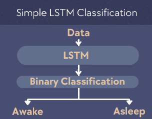

After considering computational constraints, a straightforward LSTM classifier was devised for this application. The LSTM architecture is employed to assimilate historical dataset information, facilitating the linear prediction of a child's subsequent state.

```python
# Define the model with an LSTM layer
class LSTMTokenClassifier(nn.Module):
    def __init__(self, input_size, hidden_size, num_layers, output_size):
        super(LSTMTokenClassifier, self).__init__()
        self.lstm = nn.LSTM(input_size, hidden_size, num_layers, batch_first=True)
        self.fc = nn.Linear(hidden_size, output_size)
        self.sigmoid = nn.Sigmoid()

    def forward(self, x):
        out, _ = self.lstm(x)
        out = self.fc(out)
        out = self.sigmoid(out)
        return out
```

## Impementation on New Data

We will be using the 10% of the data reserved from the original Kaggle training daya set to test our model.

```python
folder_path = "/content/drive/MyDrive/data"
test_file_paths = [os.path.join(folder_path, f"test_data_{i}.csv") for i in range(244, 270)]
wakeup=[]
sleep=[]
for file_path in test_file_paths:
    df = pd.read_csv(file_path)
    # Retrieve the indices where the column has a value equal to 1
    indices_wakeup = df.index[df['event'] == 1].tolist()
    indices_sleep = df.index[df['event'] == -1].tolist()
    indices_wakeup = [x - 2 for x in indices_wakeup]
    indices_sleep=[x - 2 for x in indices_sleep]
    wakeup.append(indices_wakeup)
    sleep.append(indices_sleep)
```

Plot Function: Each diagram's purpose will be discussed in the results.

```python
import matplotlib.pyplot as plt
import torch

def plot(input_data,output_data,pred_data,len):

    # Plotting
    plt.figure(figsize=(10, 6))
    plt.plot(input_data[0:len], label=['angelz','enmo'])
    plt.xlabel('steps')
    plt.ylabel('Value for angelz and enmo')
    plt.title('ORIGINAL DATASET')
    plt.legend()
    plt.grid(True)
    plt.show()

    plt.figure(figsize=(10, 6))
    plt.plot(output_data[0:len], label=f'Label ')
    plt.xlabel('steps')
    plt.ylabel('event happen')
    plt.title('Ground truth')
    # plt.plot(pred_data[0:len], label=f'Prediction')

    # plt.xlabel('X-axis label')
    # plt.ylabel('Y-axis label')
    # plt.title('Label')
    # plt.legend()
    # plt.grid(True)
    # plt.show()

    # plt.figure(figsize=(10, 6))

    # plt.plot(input_data[0:len], label=f'Input ')
    # plt.plot(output_data[0:len], label=f'Label ')
    plt.figure(figsize=(10, 6))
    plt.plot(pred_data[0:len], label=f'Prediction')
    plt.axvline(x=6500, color='red', linestyle='--', label='Sleep onset')
    plt.axvline(x=13000, color='green', linestyle='--', label='Wakeup')
    plt.xlabel('steps')
    plt.ylabel('prosibility')
    plt.title('Prediction Data')
    plt.legend()
    plt.grid(True)
    plt.show()

def plot_2(input_data,output_data,pred_data,len):
    plt.figure(figsize=(10, 6))
    plt.plot(pred_data[0:len], label=f'Prediction')
    plt.xlabel('steps')
    plt.ylabel('sleep or awake')
    plt.title('Prediction Data')
    plt.legend()
    plt.grid(True)
    plt.show()
```

Despite its simplicity, the training of this LSTM model proves time-consuming, particularly when handling a large dataset. Attempts were made to alleviate this by adjusting the dataset sampling time from 5 seconds to 5 minutes. However, this alteration resulted in a substantial loss of information, consequently diminishing the model's overall performance.

In response to the training challenges, the team opted to save the trained model at the completion of a 12-hour training session. The model, stored as 'model_lstm.pth,' can be readily deployed for subsequent use.

The model is designed to predict the current state based on two sets of data, namely 'angelz' and 'enmo,' where 'awake' is represented by 1, and 'sleep' is denoted by 0. The model's input comprises these two sets of data, and the output is a single value. Given the binary nature of the output (1 or 0), the LSTM model is trained using binary cross-entropy as the loss function. To expedite training and accommodate computational constraints, a smaller hidden size is employed.

Post-training, a threshold of 0.5 is set for predictions, such that predictions above this threshold classify the child as 'awake,' while those below categorize the child as 'asleep.'

It is important to note that these settings are a compromise driven by computational limitations. A more intricate LSTM model with a final output set to 2 and CrossEntropyLoss as the criterion could yield superior performance. However, the current design prioritizes faster training and operational efficiency within the given computational constraints.

Note - faster here means feasible. This model still took around 12 hours to train.

```python
# Instantiate the model
input_size = 2  # Feature size
hidden_size = 6  # LSTM hidden size
num_layers = 1  # Number of LSTM layers
output_size = 1  # Binary classification for each token
model = LSTMTokenClassifier(input_size, hidden_size, num_layers, output_size)

model_path='/content/model_lstm.pth'
# Load the saved parameters
model.load_state_dict(torch.load(model_path, map_location=torch.device('cpu')))

# Set the model to evaluation mode
model.eval()
with torch.no_grad():
    correct = 0
    total = 0
    predicted_lstm=[]
    for inputs, labels in test_loader:
        inputs=inputs
        labels = (labels + 1) / 2 # convert to range[0,1]
        labels=labels
        outputs = model(inputs.float())
        predicted = (outputs > 0.5).float()
        total += labels.numel()
        correct += (predicted.squeeze() == labels.squeeze().float()).sum().item()
        predicted_lstm.append(predicted.squeeze())

accuracy = correct / total
print(f'Test Accuracy for LSTM Classifier Model: {accuracy:.4f}')
# Now, 'loaded_model' is ready for inference
```

```
Test Accuracy for LSTM Classifier Model: 0.8337
```

## Results

Plotting these four diagrams will provide valuable insights into the model's performance and the identification of sleep onset and wakeup points. Here's a breakdown of how you can describe each diagram:

**2. Ground Truth of Original Dataset and Sleep Onset/Wakeup Points:**

The second diagram depicts the ground truth of the original dataset, emphasizing the sleep onset and wakeup points. These critical points are identified on the graph, indicating where transitions between awake and asleep states occur. This serves as a reference for evaluating the accuracy of the model's predictions.

**3. Model Predictions and Known Sleep Onset/Wakeup Points:**

Here, the graph displays the model predictions alongside the known sleep onset and wakeup points derived from the ground truth. This comparison helps assess the model's ability to correctly identify these key events. Experimentation with different thresholds for sleep/wake classification can be visually explored to optimize performance.

**4. Density-Based Sleep Onset/Wakeup Points:**

The fourth diagram introduces the concept of using density to refine sleep onset and wakeup point identification. By experimenting with various thresholds, you can evaluate the impact on the density of predicted states. High density is associated with awake states, while low density indicates sleep. The final sleep onset and wakeup points are determined based on these density patterns.

Each diagram serves a unique purpose in evaluating and refining the model's performance, providing a comprehensive analysis of its ability to predict sleep and wake states accurately.

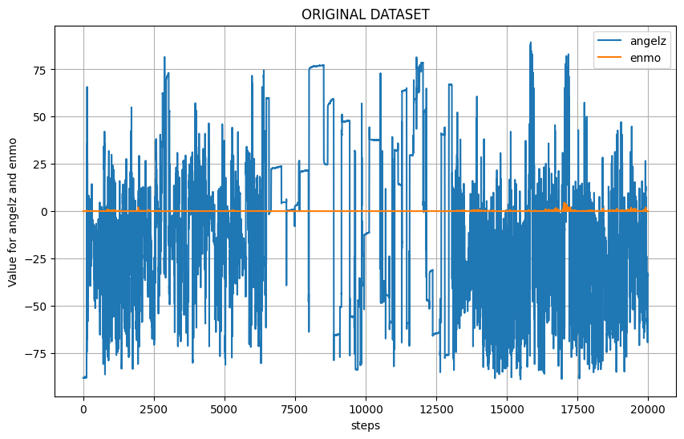

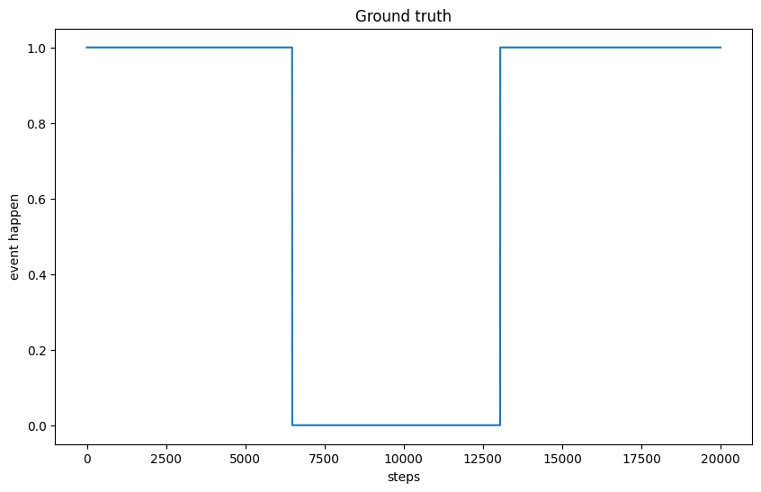

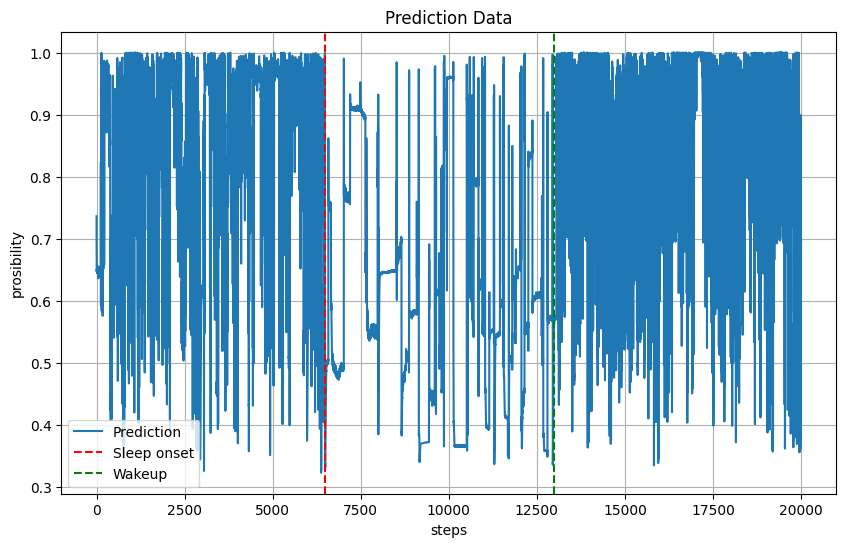

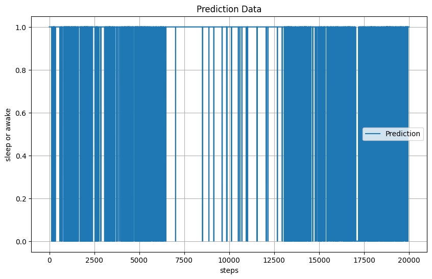

```python
model.eval()
inputs, labels=next(iter(test_loader))
labels = (labels + 1) / 2 # convert to range[0,1]
outputs = model(inputs.float())
predicted_1 = (outputs).float()
predicted_2 = ( outputs < 0.97).float()
inputs = [tensor.detach().cpu().numpy() for tensor in inputs]
labels = [tensor.detach().cpu().numpy() for tensor in labels]
predicted = [tensor.detach().cpu().numpy() for tensor in predicted_1]
plot(inputs[0],labels[0],predicted[0],20000)
predicted = [tensor.detach().cpu().numpy() for tensor in predicted_2]
plot_2(inputs[0],labels[0],predicted[0],20000)
```

# **Part 2: LSTM Autoencoder Model**

Dealing with an unballanced data such as the sleep/ wake timestamp detection can be very challenging. When facing a very sparse class in a dataset, it might be best to think of it as an anomaly detection problem, which is identifying rare instances from the majority of data which is considered to follow a normal behaviour [3].

In a more formal definition, an abnormal time point is a certain time point at which the value of the monitored variable is significantly different from those at any other time points [4]. In this comtext of this project, the duration of sleep till wake event is considered anomalous since the values are significantly different than the rest of the data. In other words, this is a case of abnormal time interval.

There are verious methods of dealing with an anomaly detection problem. Traditionally statistical indices and density of the dataset was used to identify the anomalies and involved manual development of features for a better quality of detection. However, with the rise of machine learning and deep learning specifically, the manual labour of many fields, including anomaly detection has been automated by a deep anomaly detection technology learning hierarchical discrimination features from the time series data. When faced with an abnormal time interval problem, LSTM-based and dynamic graph-based approached are among the methods that are widely used [4].

In this project, an LSTM-based approach is used, in which the general pettern of the data is fed to the model to learn to reconstruct it in a self supervised manner. Then the loss value of the reconstructed data is investigated and since there are more cases of normal behaviour, it is expected that the model will preform better at learning those intervals and the anomalous intervals will get noticed from the instances of high loss value.

## Sequencializing The Data

Furthure processing is required to prepare the data for the LSTM autoencoder. At each time a window of data is fed into the autoencoder and the model is trained to predict the next instance of data based on the received window. This means that the data needs to be turned into a sequences and the next data after each sequence is also collected as the label for the self supervised learning. The following image demonstrates the desired format of data:

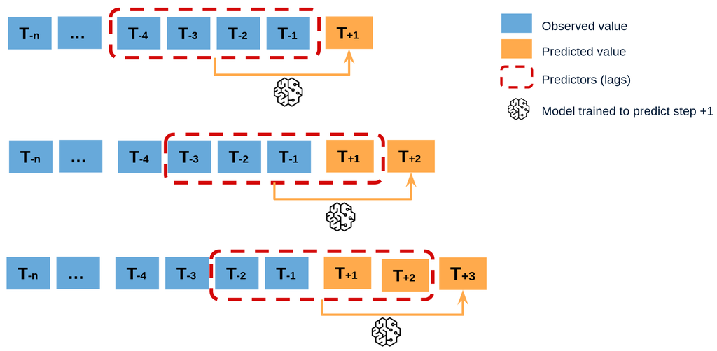

We will be taking the data from our "Data loading" section, only without changing the label to 1 and -1.

```python
# first five rows are displayed
print(data[0][:5])
```

```
     anglez      enmo  step
0  2.636719  0.021698   0.0
1  2.636719  0.021500   1.0
2  2.636719  0.021606   2.0
3  2.636719  0.021301   3.0
4  2.636719  0.021500   4.0
```

```python
#Grabs data for one specific id
#test 1 is person 1
test1 = data[0]
#glabs only the first two column, angelz and enmo
test1 = test1[test1.columns[0:2]]
```

```python
#Displaying the first 10 row of data
print(test1[:10])
```

```
     anglez      enmo
0  2.636719  0.021698
1  2.636719  0.021500
2  2.636719  0.021606
3  2.636719  0.021301
4  2.636719  0.021500
5  2.636719  0.021698
6  2.636719  0.021698
7  2.636719  0.021805
8  2.798828  0.022293
9  3.083984  0.021698
```

Upon working with the model, different scale of these two features causes problems with the learning process. Specifically, the loss value was not low enough for the model to learn anything from "enmo" and only "anglez" was reconstructed. To address this issue the features were normalized using z-score normalization. z-score normalization is a feature scaling method, inw which standardizes the data to have the mean of 0 and standard deviation of 1 using the formula below:

new data = (𝔁 - 𝝁)/𝛔

The cell below preforms the same operation:

```python
from sklearn.preprocessing import StandardScaler

scaler = StandardScaler()
test1_scaled = pd.DataFrame(scaler.fit_transform(test1), columns=test1.columns)
```

```python
#Displaying the first 10 row of data
print(test1_scaled[:10])
```

```
     anglez      enmo
0  0.433838 -0.180420
1  0.433838 -0.183105
2  0.433838 -0.181641
3  0.433838 -0.185913
4  0.433838 -0.183105
5  0.433838 -0.180420
6  0.433838 -0.180420
7  0.433838 -0.178955
8  0.437988 -0.172241
9  0.445312 -0.180420
```

Now, the sequencialization takes place. The default window size is set to 5:

```python
def df_to_X_y(df, window_size=5):
    df_as_np = df.to_numpy()
    X = []
    y = []
    for i in range(len(df_as_np)-window_size):
        row = [[a] for a in df_as_np[i:i+window_size]]
        X.append(row)
        label = df_as_np[i+window_size]
        y.append(label)
    return np.array(X), np.array(y)
```

```python
WINDOW_SIZE = 5
X1, y1 = df_to_X_y(test1_scaled, WINDOW_SIZE)
X1.shape, y1.shape
```

```
((389875, 5, 1, 2), (389875, 2))
```

## Model Architecture

The Model architecture accompanied by an illustration/diagram can be found below:

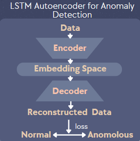

LSTM is designed to manage long-term dependencies more effectively. The LSTM architecture incorporates a storage unit and gating mechanism, enabling it to selectively update and retain information throughout extended sequences, thereby alleviating the gradient disappearance problem. These characteristics makes LSTM a proper architecture to use when dealing with time series data. Using them for this purpose is also supported by various sources [4-5].

The following architecture was used which consists of two parts of a four layers encoder followed by a four layer decoder.

```python
window_size = 5
num_features = 2

import tensorflow as tf
from tensorflow.keras.models import Sequential
from tensorflow.keras.layers import LSTM, RepeatVector, TimeDistributed, Dense


model = Sequential()
model.add(LSTM(16, activation='relu', input_shape = (window_size, num_features), return_sequences=True))
model.add(BatchNormalization())
model.add(LSTM(32, activation='relu', return_sequences=True))
model.add(BatchNormalization())
model.add(LSTM(64, activation='relu', return_sequences=True))
model.add(BatchNormalization())
model.add(LSTM(128, activation='relu', return_sequences=False))
model.add(BatchNormalization())

model.add(RepeatVector(window_size))
model.add(LSTM(128, activation='relu', input_shape=(window_size, 128), return_sequences=True))
model.add(BatchNormalization())
model.add(LSTM(64, activation='relu', return_sequences=True))
model.add(BatchNormalization())
model.add(LSTM(32, activation='relu', return_sequences=True))
model.add(BatchNormalization())
model.add(LSTM(16, activation='relu', return_sequences=True))
model.add(BatchNormalization())
model.add(TimeDistributed(Dense(num_features, activation='relu')))

optimizer = tf.keras.optimizers.Adam(learning_rate=0.0001, clipvalue=0.5)
model.compile(optimizer=optimizer, loss='mae')
```

```python
model.summary()
```

```
Model: "sequential"
_________________________________________________________________
 Layer (type)                Output Shape              Param #
=================================================================
 lstm (LSTM)                 (None, 5, 16)             1216

 batch_normalization (Batch  (None, 5, 16)             64
 Normalization)

 lstm_1 (LSTM)               (None, 5, 32)             6272

 batch_normalization_1 (Bat  (None, 5, 32)             128
 chNormalization)

 lstm_2 (LSTM)               (None, 5, 64)             24832

 batch_normalization_2 (Bat  (None, 5, 64)             256
 chNormalization)

 lstm_3 (LSTM)               (None, 128)               98816

 batch_normalization_3 (Bat  (None, 128)               512
 chNormalization)

 repeat_vector (RepeatVecto  (None, 5, 128)            0
 r)

 lstm_4 (LSTM)               (None, 5, 128)            131584

 batch_normalization_4 (Bat  (None, 5, 128)            512
 chNormalization)

 lstm_5 (LSTM)               (None, 5, 64)             49408

 batch_normalization_5 (Bat  (None, 5, 64)             256
 chNormalization)

 lstm_6 (LSTM)               (None, 5, 32)             12416

 batch_normalization_6 (Bat  (None, 5, 32)             128
 chNormalization)

 lstm_7 (LSTM)               (None, 5, 16)             3136

 batch_normalization_7 (Bat  (None, 5, 16)             64
 chNormalization)

 time_distributed (TimeDist  (None, 5, 2)              34
 ributed)

=================================================================
Total params: 329634 (1.26 MB)
Trainable params: 328674 (1.25 MB)
Non-trainable params: 960 (3.75 KB)
_________________________________________________________________
```

The Adam optimizer and mean absolute error as loss function was used. Batch size, learning rate, number of epochs, number of layers of encoder/decoder, hidden layers of LSTMs and window size are all among the hyperparameters that was tuned. However, the hyperparameters do not end here as we made things more complicated. When this model was used initially, despite capturing some points as anomaly, they were not properlly overlapping with the event labels. This issue was caused by the fact that up to this point the labels (timestamp of events) were not used and this was only a self supervised method.

```python
def nearest_neighbor(anomalies, label):

  num_anomalies = K.shape(anomalies)[0]
  NN = tf.fill((num_anomalies,), 10000.0)
  for i in range(num_anomalies):
      differences = K.abs(anomalies[i] - label)
      indices = tf.argmin(differences)
      value = tf.gather(label, indices)
      index = tf.convert_to_tensor([i], dtype=tf.int32)
      value = tf.cast(value, dtype=NN.dtype)
      updates = tf.tensor_scatter_nd_update(NN, tf.expand_dims(index, axis=-1), [value])
      NN = tf.where(updates < NN, updates, NN)

  return NN
```

```python
def custom_loss_wrapper(Labels, loss_weight):
  def custom_loss(y_true, y_pred):
    # Reconstruction loss
    reconstruction_loss = K.mean(K.square(y_true - y_pred), axis=[1, 2])


    # Anomaly detection loss (MAE)
    loss = K.mean(K.abs(y_true - y_pred), axis=1)
    threshold_f1 = tfp.stats.percentile(loss[:, 0], 70)  # Adjust value as needed
    threshold_f2 = tfp.stats.percentile(loss[:, 1], 99)  # Adjust value as needed

    is_anomaly1 = K.cast((loss[:, 0] > threshold_f1), K.floatx())
    is_anomaly2 = K.cast((loss[:, 1] > threshold_f2), K.floatx())

    label = list(x/1 for x in chain(*Labels))

    NN1 = nearest_neighbor(is_anomaly1, label)
    NN2 = nearest_neighbor(is_anomaly2, label)

    anomaly_loss1 = K.mean(K.abs(is_anomaly1 - NN1))
    anomaly_loss2 = K.mean(K.abs(is_anomaly2 - NN2))

    anomaly_loss = (1.2*anomaly_loss1 + anomaly_loss2)/2   # Adjust the weight as needed

    # Combining the losses using a weight
    combined_loss = loss_weight[0] * reconstruction_loss + loss_weight[1] * anomaly_loss  # Adjust the weight as needed

    return combined_loss
  return custom_loss
```

```python
def train(Train_X, Train_y, Labels, batch_size=200, epochs=1, learning_rate=0.0001, loss_weight=[1,0.5]):

  optimizer = tf.keras.optimizers.Adam(learning_rate=learning_rate, clipvalue=0.5)
  loss_function = custom_loss_wrapper(Labels, loss_weight)
  autoencoder = load_model('/content/bs200_ep10_lr0.0001_ws5_mse_10people.h5')
  autoencoder.compile(optimizer=optimizer, loss=loss_function)

  history=autoencoder.fit(Train_X.squeeze(), np.expand_dims(Train_y, 1), epochs=epochs, batch_size=batch_size, validation_split=0.1, shuffle=False)

  plt.plot(history.history['loss'])
  plt.plot(history.history['val_loss'])
  plt.show()

  return autoencoder
```

The process of getting to this point and optimizing the training process in such manner did not happen in one go. That's why in each step we used the best model achieved with previous precedures as initial weights and loaded them for further training.

And the weights for how important each of those losses are, the threshold given to each feature to find the anomalies and how the distance of anomalies in each feature from the events are priorotized are all among the hyperparameters that were tuned.

Eventually we setteled on the following hyperparameters:

- Batch size: 200
- Learning rate: 0.0001
- number of epochs: 10
- Number of layers: 4 for encoder and 4 for decoder
- Weight of reconstruction loss: 1
- Weight of anomaly loss: 0.5
- Threshold for enmo: 99
- Threshold for anglez: 70
- Weight for enmo: 1
- Weight for anglez: 1.2

Eventhough better results could've been achieved by using more epochs, the training was very very slow and the projects time constraint prevented us from increasing the epochs to more than 10.

Using the values above the following training curve was achieved:

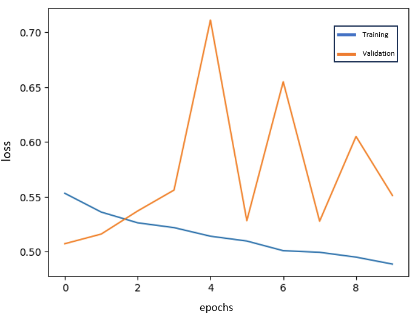

## Results

This method does not contain a classifier and is meant to identify the events visually. In order to do so the same data that was used to train the model is fed into it once again to receive the reconstructed version as output. Then, the loss asspcoated with the reconstrcuted version and original version is computed and drawn for each feature.

The timestamp of the events are also displayed on the graph to check how they line up.

The following graph was achieved using the method explained above:

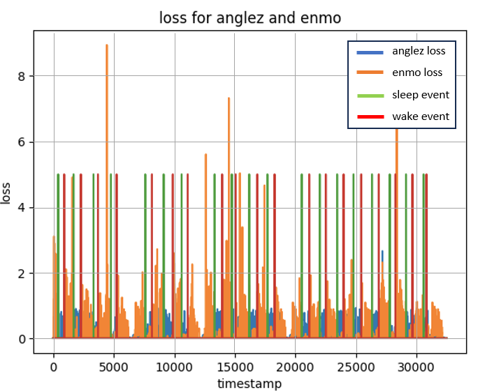

As it can be seen, the events do not exactly line up with the highest values of loss yet, however the event markers identify the regions with high loss with high precision.

## Implementation on New Data

To test the model on new data, the model that was saved from previous section was loaded and new data was fed into the model.

The output would be the reconstructed data and in order to find the anomalies the loss graph for each of the features along the time series were visualized.

In the training phase, it was noticed that the reconstructed loss contains a region of anomalies (high loss values) that lines up with the event markers, however the highest loss value doen't necessarily conincide with the events.

In order to address this issue one more step was added in which the derivative of the loss values were also visualized to see if the jump points on the graph can be used to identify the events.

The following cells demonstrate the process described above for a set of data that the model hasn't been exposed to before:

```python
#from custom_loss_wrapper import custom_loss
from itertools import chain
import tensorflow as tf
from tensorflow.keras import backend as K
import tensorflow_probability as tfp
loss_function = custom_loss_wrapper(test_labels, loss_weight=[1,1])
autoencoder = load_model('/content/bs200_ep10_lr0.0001_ws5_mse_10people.h5')
autoencoder.compile(optimizer=optimizer, loss=loss_function)
autoencoder = load_model('/content/best_model_29_nov.h5', custom_objects={'custom_loss': loss_function})
```

```python
#finds sleep time stamp
graph_s = np.zeros(len(mse_loss))

for i, values in enumerate(test_labels):
  graph_s[int(values[0])] = 5         #Visualizing sleep events
```

```python
#finds awake time stamp
graph_a = np.zeros(len(mse_loss))

for i, values in enumerate(test_labels):
  graph_a[int(values[1])] = 5        #Visualizing wake events
```

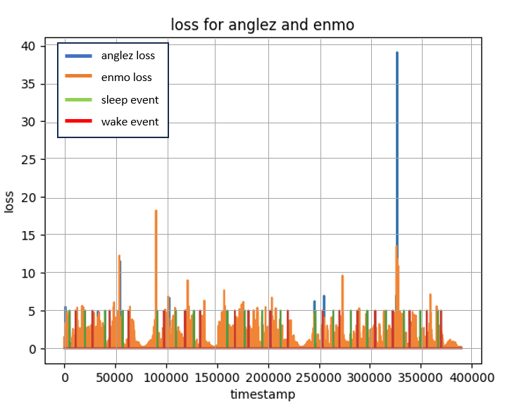

```python
# displaying loss for each feature in all the timestamps to find anomalies
import seaborn as sns
import copy

# making a deep copy to not affect the original data
X = copy.deepcopy(X_test)
pred = autoencoder.predict(X.squeeze())
mse_loss = np.mean(np.abs(pred, X.squeeze()), axis=1)
print(mse_loss.shape)

#show loss for anglez (comment if not needed)
#plt.plot(mse_loss[:,0])
#plt.title('loss for anglez')
#plt.ylabel('loss')
#plt.xlabel('timestamp')
#plt.show()

#show loss for enmo   (comment if not needed)
#plt.plot(mse_loss[:,1])
#plt.title('loss for enmo')
#plt.ylabel('loss')
#plt.xlabel('timestamp')
#plt.show()

#show loss for both   (comment if not needed)
plt.plot(mse_loss, label=('anglez', 'enmo'))
plt.title('loss for anglez and enmo')
plt.ylabel('loss')
plt.xlabel('timestamp')
plt.plot(graph_s, label='sleep')
plt.plot(graph_a, label='wake up')
plt.show()
```

Up to this point, the same precedure as before has been done and it's evident that the model isn't prefectly attuned to visualize this data as the markers don't line up with the change points as perfectly as before.

However, by doing that one further step, better results was achieved:

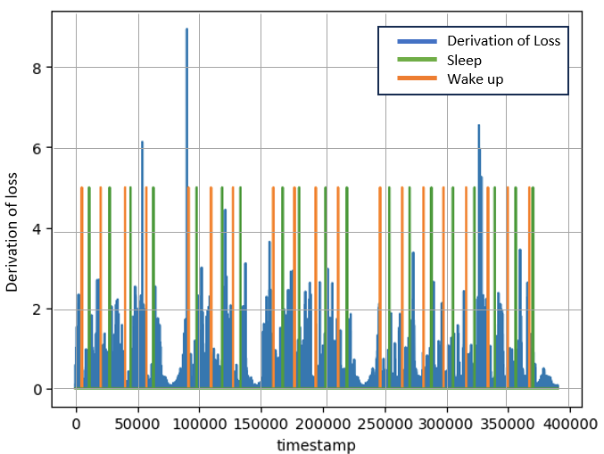

```python
import numpy as np
derivative = np.gradient(mse_loss[:,1], range(len(mse_loss[:,1])))

plt.plot(abs(derivative))
plt.ylabel('der')
plt.xlabel('timestamp')
plt.plot(graph_s, label='sleep')
plt.plot(graph_a, label='wake up')
plt.show()
```

This time we see that the high values of loss in each local region does approximately line up with the event markers, showing that the model is capable of generalizing.

# **Discussion**

This project presented many challenges. A huge problem that we dealt with was the sheer amount of data that we were given and the unbalanced nature of the data only complicated the issue further. Only 0.01% of our data was a sleep onset/wake event. This complicated the task for two reasons:

1. For a normal classification problem, if we had an unbalanced dataset, we would typically balance it by either collecting more data for the “minority” group or, by under-representing the “majority” group. Since the data that we had however was time-series data, we could not over-represent the occurrence of sleep onset/wake events.
2. Due to the vast amount of data in each observation, and since since sleep/wake events only occurred once in each observation, to be able to create a reliable model, we knew we had to find a way to use as many observations as possible during training. This meant that we needed to ensure that our model not only produced reliable results, but was as computationally efficient as possible.

In order to train our model on as many observations as possible to effectively tune the models, we used smaller subsets of the training data and by limiting the number of observations in each smaller training set and by using data taken at longer intervals of time (i.e. rather than the defualt 5 seconds).

We also relaized that to be able to pinpoint the transitional sleep/ wake events, the model had to be able to diffrentiate between when the individual was sleeping vs when they were awake. As you may have noticed in the data section when we visualized individual observations, the states of being awake or asleep seemed to be associated with very specific enmo and anglez pattern (higher density for both metric when awake compared to asleep) but, sleep/wake *events* did not seem to be associated with a specific anglez or enmo value or range of values.

This told us that to be able to identify when sleep/wake events occur, we’d need to be to track enmo/ anglez values to be able to identify when the person was awake, or asleep and this would allow us to identify events by identifying the junction between the two states.

This is why we chose to investigate this problem by implementing an LSTM autoencoder and an LSTM binary classifier.

Overall, the LSTM autoencoder is capable of recontrsucting the data in such a manner that by visualizing the loss for each feature and following the change points on them (either by just looking or finsing the derivation of loss) the events of sleep and wake up can be identified.

# **Conclusions**

We chose to complete a project that was difficult and to develop a novel solution to the problem because we wanted to challenge ourselves. We quickly realized that a large part of our problem was figuring out how to deal with the data that we were given. When we were finally ready to use the complete data allocated to training, members of the team spent 10 - 12 hours training our models. By the end of the project, we had exhausted all our Colab Pro compute units.

We learned that when dealing with data in the real world to create novel solutions, especially for problems as challenging as the one we faced, a significant barrier is computational power, as such, it is incredibly important to be able to build computationally efficient solutions. Due to sequential nature of time series, for us this meant building RNN based model. We also found that having features with different scale can cause the training phase of the model to stagnate and normalizing them can prevent that problem.

## Next Steps

As you may have noticed in the initial visualizations of the data in the “Data Description” section, the “sleep” period exhibits spikes in enmo and anglez. We believe the presence of these ‘spikes’ in activity may correspond to non-REM sleep. REM sleep is the phase of sleep that “dreaming” occurs, and the distribution of REM and non-REM sleep can be incredibly informative when learning about sleep quality and sleep disorders. By further building on our model, we may in the future be able to use enmo and anglez to differentiate between non-REM and REM sleep.

Our results could also be used to improve technology outside of the lab. In the past few years, we have seen a boom in biological wearable technology. Since our solution is based on wrist worn accelerometer data and since pinpointing sleep/ wake accurately has been a significant barrier in sleep research in the past, this means that wearables on the market today (i.e., fitbits, applewatchs etc.) do not have accurate estimates for when sleep onset and wake occur. Many people depend on biological wearables to make personalized health predictions. Wearables can even be used by doctors to gain a deeper understanding of their patient’s symptoms. We believe that with our findings, sleep/wake estimates made by these technologiez could be made more accurate.

## Related Works

[7] **DeepSleepNet:** This study introduced a deep learning model that uses single-channel EEG data to classify sleep stages. It employs Convolutional Neural Networks and bidirectional LSTMs to detect sleep stages, sidestepping the need for manual feature engineering.

[8] **U-Time**: This research presented a fully feed-forward deep learning method designed specifically for physiological time-series sleep data analysis. With its roots in the U-Net architecture, U-Time has proven to be robust and reliable in segmenting sleep EEG datasets.

[9] **DOSED:** This study unveiled the Dreem One Shot Event Detector (DOSED), a deep learning architecture aimed at annotating sleep-related events in EEG time series. It's versatile and can predict multiple parameters of sleep events, showcasing a performance improvement over traditional methods.

[10] **SeqSleepNet:** This research introduced a hierarchical recurrent neural network designed specifically for sleep staging. It takes a sequence-to-sequence approach, enabling it to classify multiple sleep epochs simultaneously.

[11] **Dreem Open Datasets:** This study introduced two datasets for sleep stage classification and developed a deep learning model, SimpleSleepNet. The research emphasizes the potential advantages of automated methods over human evaluation in clinical settings, especially in diagnosing sleep disorders.

# **Citations**

1. Hibbeln, M. A third of Canadians are only getting three or fewer nights of restful sleep per week. Narrative Research https://narrativeresearch.ca/a-third-of-canadians-are-only-getting-three-or-fewer-nights-of-restful-sleep-per-week/ (2023).
2. Lacaux, C. et al. Sleep onset is a creative sweet spot. Sci. Adv. 7, eabj5866.
3. Wikipedia. (2023, December 4). Anomaly detection. https://en.wikipedia.org/wiki/Anomaly_detection
4. Gen Li, Jason J. Jung, "Deep learning for anomaly detection in multivariate time series: Approaches, applications, and challenges", Information Fusion Volume 91, 2023, Pages 93-102, ISSN 1566-2535, https://doi.org/10.1016/j.inffus.2022.10.008.
5. R. Li, B. Wang, T. Zhang and T. Sugi, "A Developed LSTM-Ladder-Network-Based Model for Sleep Stage Classification," in IEEE Transactions on Neural Systems and Rehabilitation Engineering, vol. 31, pp. 1418-1428, 2023, https://doi.org/10.1109/TNSRE.2023.3246478.
6. Sepehr Maleki, Sasan Maleki, Nicholas R. Jennings, "Unsupervised anomaly detection with LSTM autoencoders using statistical data-filtering", Applied Soft Computing, Volume 108, 2021, 107443, ISSN 1568-4946, https://doi.org/10.1016/j.asoc.2021.107443.
7. Supratak, A., Dong, H., Wu, C., & Guo, Y. (2017). DeepSleepNet: A Model for Automatic Sleep Stage Scoring Based on Raw Single-Channel EEG. IEEE Transactions on Neural Systems and Rehabilitation Engineering, 25(11), 1998–2008. https://doi.org/10.1109/TNSRE.2017.2721116
8. Perslev, M., Jensen, M. H., Darkner, S., Jennum, P. J., & Igel, C. (2019, October 24). U-Time: A Fully Convolutional Network for Time Series Segmentation Applied to Sleep Staging. arXiv.Org. https://arxiv.org/abs/1910.11162v1
9. Chambon, S., Thorey, V., Arnal, P. J., Mignot, E., & Gramfort, A. (2019). DOSED: A deep learning approach to detect multiple sleep micro-events in EEG signal. Journal of Neuroscience Methods, 321, 64–78. https://doi.org/10.1016/j.jneumeth.2019.03.017
10. Phan, H., Andreotti, F., Cooray, N., Chén, O. Y., & De Vos, M. (2019). SeqSleepNet: End-to-End Hierarchical Recurrent Neural Network for Sequence-to-Sequence Automatic Sleep Staging. IEEE Transactions on Neural Systems and Rehabilitation Engineering, 27(3), 400–410. https://doi.org/10.1109/TNSRE.2019.2896659
11. Guillot, A., Sauvet, F., During, E. H., & Thorey, V. (2020). Dreem Open Datasets: Multi-Scored Sleep Datasets to Compare Human and Automated Sleep Staging. IEEE Transactions on Neural Systems and Rehabilitation Engineering, 28(9), 1955–1965. https://doi.org/10.1109/TNSRE.2020.3011181

```python
%%shell
jupyter nbconvert --to html /content/Sleep_States_Writing_Sample.ipynb
```

```
[NbConvertApp] Converting notebook /content/Sleep_States_Writing_Sample.ipynb to html
[NbConvertApp] WARNING | Alternative text is missing on 4 image(s).
[NbConvertApp] Writing 1483656 bytes to /content/Sleep_States_Writing_Sample.html
```